# US House Market Prediction

```python
import copy
import warnings

import joblib
import matplotlib.pyplot as plt
import numpy as np
import pandas as pd
import seaborn as sns
import torch
import torch.nn as nn
import torchinfo
import tqdm
from geopy.geocoders import Nominatim
from sklearn.metrics import r2_score
from sklearn.model_selection import train_test_split
from sklearn.preprocessing import RobustScaler, StandardScaler
from torch.optim.lr_scheduler import ReduceLROnPlateau, StepLR
from torch.utils.data import DataLoader, TensorDataset

warnings.filterwarnings('ignore')
```

## Data Loading

```python
df = pd.read_csv('datasets/realtordataUS.csv', encoding='UTF-8')
df
```

|  | brokered_by | status | price | bed | bath | acre_lot | street | city | state | zip_code | house_size | prev_sold_date |
| --- | --- | --- | --- | --- | --- | --- | --- | --- | --- | --- | --- | --- |
| 0 | 103378.0 | for_sale | 105000.0 | 3.0 | 2.0 | 0.12 | 1962661.0 | Adjuntas | Puerto Rico | 601.0 | 920.0 | NaN |
| 1 | 52707.0 | for_sale | 80000.0 | 4.0 | 2.0 | 0.08 | 1902874.0 | Adjuntas | Puerto Rico | 601.0 | 1527.0 | NaN |
| 2 | 103379.0 | for_sale | 67000.0 | 2.0 | 1.0 | 0.15 | 1404990.0 | Juana Diaz | Puerto Rico | 795.0 | 748.0 | NaN |
| 3 | 31239.0 | for_sale | 145000.0 | 4.0 | 2.0 | 0.10 | 1947675.0 | Ponce | Puerto Rico | 731.0 | 1800.0 | NaN |
| 4 | 34632.0 | for_sale | 65000.0 | 6.0 | 2.0 | 0.05 | 331151.0 | Mayaguez | Puerto Rico | 680.0 | NaN | NaN |
| ... | ... | ... | ... | ... | ... | ... | ... | ... | ... | ... | ... | ... |
| 2226377 | 23009.0 | sold | 359900.0 | 4.0 | 2.0 | 0.33 | 353094.0 | Richland | Washington | 99354.0 | 3600.0 | 2022-03-25 |
| 2226378 | 18208.0 | sold | 350000.0 | 3.0 | 2.0 | 0.10 | 1062149.0 | Richland | Washington | 99354.0 | 1616.0 | 2022-03-25 |
| 2226379 | 76856.0 | sold | 440000.0 | 6.0 | 3.0 | 0.50 | 405677.0 | Richland | Washington | 99354.0 | 3200.0 | 2022-03-24 |
| 2226380 | 53618.0 | sold | 179900.0 | 2.0 | 1.0 | 0.09 | 761379.0 | Richland | Washington | 99354.0 | 933.0 | 2022-03-24 |
| 2226381 | 108243.0 | sold | 580000.0 | 5.0 | 3.0 | 0.31 | 307704.0 | Richland | Washington | 99354.0 | 3615.0 | 2022-03-23 |

2226382 rows × 12 columns

### Null/Missing Values Check

```python
df.isnull().sum()
```

```
brokered_by         4533
status                 0
price               1541
bed               481317
bath              511771
acre_lot          325589
street             10866
city                1407
state                  8
zip_code             299
house_size        568484
prev_sold_date    734297
dtype: int64
```

### Statistics of Dataset

```python
df.describe()
```

|  | brokered_by | price | bed | bath | acre_lot | street | zip_code | house_size |
| --- | --- | --- | --- | --- | --- | --- | --- | --- |
| count | 2.221849e+06 | 2.224841e+06 | 1.745065e+06 | 1.714611e+06 | 1.900793e+06 | 2.215516e+06 | 2.226083e+06 | 1.657898e+06 |
| mean | 5.293989e+04 | 5.241955e+05 | 3.275841e+00 | 2.496440e+00 | 1.522303e+01 | 1.012325e+06 | 5.218668e+04 | 2.714471e+03 |
| std | 3.064275e+04 | 2.138893e+06 | 1.567274e+00 | 1.652573e+00 | 7.628238e+02 | 5.837635e+05 | 2.895408e+04 | 8.081635e+05 |
| min | 0.000000e+00 | 0.000000e+00 | 1.000000e+00 | 1.000000e+00 | 0.000000e+00 | 0.000000e+00 | 0.000000e+00 | 4.000000e+00 |
| 25% | 2.386100e+04 | 1.650000e+05 | 3.000000e+00 | 2.000000e+00 | 1.500000e-01 | 5.063128e+05 | 2.961700e+04 | 1.300000e+03 |
| 50% | 5.288400e+04 | 3.250000e+05 | 3.000000e+00 | 2.000000e+00 | 2.600000e-01 | 1.012766e+06 | 4.838200e+04 | 1.760000e+03 |
| 75% | 7.918300e+04 | 5.500000e+05 | 4.000000e+00 | 3.000000e+00 | 9.800000e-01 | 1.521173e+06 | 7.807000e+04 | 2.413000e+03 |
| max | 1.101420e+05 | 2.147484e+09 | 4.730000e+02 | 8.300000e+02 | 1.000000e+05 | 2.001357e+06 | 9.999900e+04 | 1.040400e+09 |

## Data Cleaning

First we will drop all unncessary columns in the dataset

```python
df = df.drop(columns=["brokered_by", "status", "street", "prev_sold_date"])
df
```

|  | price | bed | bath | acre_lot | city | state | zip_code | house_size |
| --- | --- | --- | --- | --- | --- | --- | --- | --- |
| 0 | 105000.0 | 3.0 | 2.0 | 0.12 | Adjuntas | Puerto Rico | 601.0 | 920.0 |
| 1 | 80000.0 | 4.0 | 2.0 | 0.08 | Adjuntas | Puerto Rico | 601.0 | 1527.0 |
| 2 | 67000.0 | 2.0 | 1.0 | 0.15 | Juana Diaz | Puerto Rico | 795.0 | 748.0 |
| 3 | 145000.0 | 4.0 | 2.0 | 0.10 | Ponce | Puerto Rico | 731.0 | 1800.0 |
| 4 | 65000.0 | 6.0 | 2.0 | 0.05 | Mayaguez | Puerto Rico | 680.0 | NaN |
| ... | ... | ... | ... | ... | ... | ... | ... | ... |
| 2226377 | 359900.0 | 4.0 | 2.0 | 0.33 | Richland | Washington | 99354.0 | 3600.0 |
| 2226378 | 350000.0 | 3.0 | 2.0 | 0.10 | Richland | Washington | 99354.0 | 1616.0 |
| 2226379 | 440000.0 | 6.0 | 3.0 | 0.50 | Richland | Washington | 99354.0 | 3200.0 |
| 2226380 | 179900.0 | 2.0 | 1.0 | 0.09 | Richland | Washington | 99354.0 | 933.0 |
| 2226381 | 580000.0 | 5.0 | 3.0 | 0.31 | Richland | Washington | 99354.0 | 3615.0 |

2226382 rows × 8 columns

We will also drop all null values present in the dataset since there are tons from the Null Value Check

```python
df = df.dropna()
df
```

|  | price | bed | bath | acre_lot | city | state | zip_code | house_size |
| --- | --- | --- | --- | --- | --- | --- | --- | --- |
| 0 | 105000.0 | 3.0 | 2.0 | 0.12 | Adjuntas | Puerto Rico | 601.0 | 920.0 |
| 1 | 80000.0 | 4.0 | 2.0 | 0.08 | Adjuntas | Puerto Rico | 601.0 | 1527.0 |
| 2 | 67000.0 | 2.0 | 1.0 | 0.15 | Juana Diaz | Puerto Rico | 795.0 | 748.0 |
| 3 | 145000.0 | 4.0 | 2.0 | 0.10 | Ponce | Puerto Rico | 731.0 | 1800.0 |
| 5 | 179000.0 | 4.0 | 3.0 | 0.46 | San Sebastian | Puerto Rico | 612.0 | 2520.0 |
| ... | ... | ... | ... | ... | ... | ... | ... | ... |
| 2226377 | 359900.0 | 4.0 | 2.0 | 0.33 | Richland | Washington | 99354.0 | 3600.0 |
| 2226378 | 350000.0 | 3.0 | 2.0 | 0.10 | Richland | Washington | 99354.0 | 1616.0 |
| 2226379 | 440000.0 | 6.0 | 3.0 | 0.50 | Richland | Washington | 99354.0 | 3200.0 |
| 2226380 | 179900.0 | 2.0 | 1.0 | 0.09 | Richland | Washington | 99354.0 | 933.0 |
| 2226381 | 580000.0 | 5.0 | 3.0 | 0.31 | Richland | Washington | 99354.0 | 3615.0 |

1360347 rows × 8 columns

We also want to drop all duplicate rows if there are any.

```python
df = df.drop_duplicates()
df
```

|  | price | bed | bath | acre_lot | city | state | zip_code | house_size |
| --- | --- | --- | --- | --- | --- | --- | --- | --- |
| 0 | 105000.0 | 3.0 | 2.0 | 0.12 | Adjuntas | Puerto Rico | 601.0 | 920.0 |
| 1 | 80000.0 | 4.0 | 2.0 | 0.08 | Adjuntas | Puerto Rico | 601.0 | 1527.0 |
| 2 | 67000.0 | 2.0 | 1.0 | 0.15 | Juana Diaz | Puerto Rico | 795.0 | 748.0 |
| 3 | 145000.0 | 4.0 | 2.0 | 0.10 | Ponce | Puerto Rico | 731.0 | 1800.0 |
| 5 | 179000.0 | 4.0 | 3.0 | 0.46 | San Sebastian | Puerto Rico | 612.0 | 2520.0 |
| ... | ... | ... | ... | ... | ... | ... | ... | ... |
| 2226377 | 359900.0 | 4.0 | 2.0 | 0.33 | Richland | Washington | 99354.0 | 3600.0 |
| 2226378 | 350000.0 | 3.0 | 2.0 | 0.10 | Richland | Washington | 99354.0 | 1616.0 |
| 2226379 | 440000.0 | 6.0 | 3.0 | 0.50 | Richland | Washington | 99354.0 | 3200.0 |
| 2226380 | 179900.0 | 2.0 | 1.0 | 0.09 | Richland | Washington | 99354.0 | 933.0 |
| 2226381 | 580000.0 | 5.0 | 3.0 | 0.31 | Richland | Washington | 99354.0 | 3615.0 |

1259352 rows × 8 columns

We also want to remove outliers such as houses with 10 or more bedrooms/bathrooms (these could be buildings, multi-family residentals, extreme luxary mansions, or data entry errors)

```python
df = df[(df['bed'] < 10) & (df['bath'] < 10) & (df['price'] > 50000) & (df['price'] < 50000000)]
df
```

|  | price | bed | bath | acre_lot | city | state | zip_code | house_size |
| --- | --- | --- | --- | --- | --- | --- | --- | --- |
| 0 | 105000.0 | 3.0 | 2.0 | 0.12 | Adjuntas | Puerto Rico | 601.0 | 920.0 |
| 1 | 80000.0 | 4.0 | 2.0 | 0.08 | Adjuntas | Puerto Rico | 601.0 | 1527.0 |
| 2 | 67000.0 | 2.0 | 1.0 | 0.15 | Juana Diaz | Puerto Rico | 795.0 | 748.0 |
| 3 | 145000.0 | 4.0 | 2.0 | 0.10 | Ponce | Puerto Rico | 731.0 | 1800.0 |
| 5 | 179000.0 | 4.0 | 3.0 | 0.46 | San Sebastian | Puerto Rico | 612.0 | 2520.0 |
| ... | ... | ... | ... | ... | ... | ... | ... | ... |
| 2226377 | 359900.0 | 4.0 | 2.0 | 0.33 | Richland | Washington | 99354.0 | 3600.0 |
| 2226378 | 350000.0 | 3.0 | 2.0 | 0.10 | Richland | Washington | 99354.0 | 1616.0 |
| 2226379 | 440000.0 | 6.0 | 3.0 | 0.50 | Richland | Washington | 99354.0 | 3200.0 |
| 2226380 | 179900.0 | 2.0 | 1.0 | 0.09 | Richland | Washington | 99354.0 | 933.0 |
| 2226381 | 580000.0 | 5.0 | 3.0 | 0.31 | Richland | Washington | 99354.0 | 3615.0 |

1239185 rows × 8 columns

## Visualization & Exploratory Data Analysis

Lets first see the count of all priced houses. If we do it regularly its incredibly difficult to see due to the outliers and they dominate the scale of our plot. We can then use a logarithmic scale to further see the relationships.

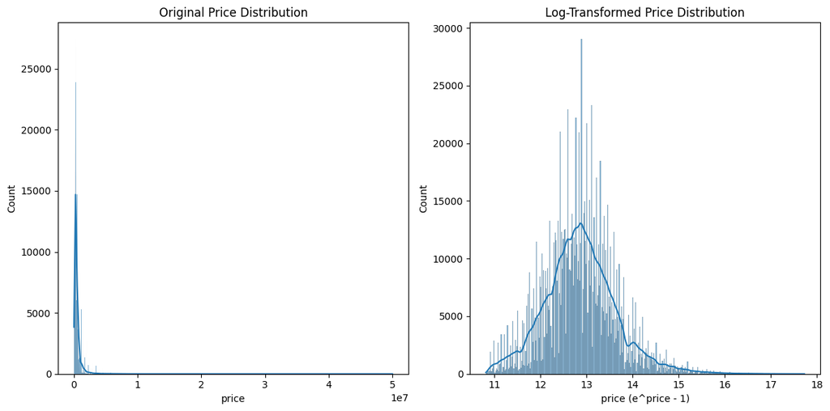

```python
# Apply log transformation to Price
prices = np.log1p(df['price'])  # log1p handles log(1 + x), avoiding log(0)

# Visualize the original and transformed distributions
plt.figure(figsize=(12, 6))

# Original Price Distribution
plt.subplot(1, 2, 1)
sns.histplot(df['price'], kde=True)
plt.title('Original Price Distribution')

# Log-Transformed Price Distribution
plt.subplot(1, 2, 2)
sns.histplot(prices, kde=True)
plt.title('Log-Transformed Price Distribution')
plt.xlabel("price (e^price - 1)")

plt.tight_layout()
plt.show()
```

We can also plot this dataset using a heat map to show the correlation matrix of all numerical features.

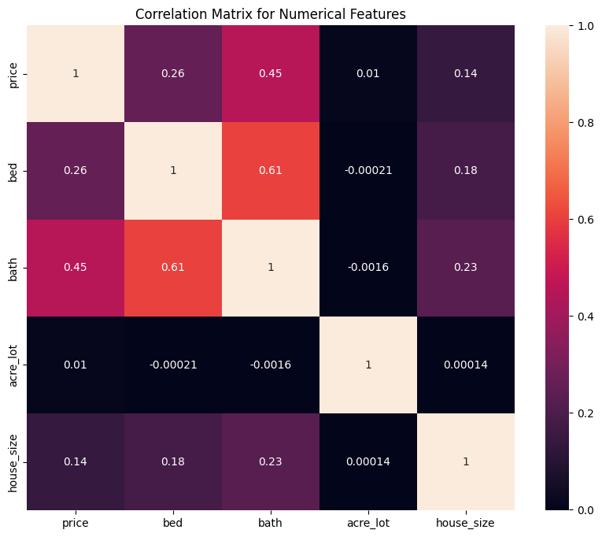

```python
# Compute the correlation matrix
corr_columns = ['price', 'bed', 'bath', 'acre_lot', 'house_size']
corr_matrix = df[corr_columns].corr()

# Plot the heatmap
plt.figure(figsize=(10, 8))
sns.heatmap(corr_matrix, annot=True)
plt.title('Correlation Matrix for Numerical Features')
plt.show()
```

Here is the correlation graphings and the pairplots for all features as well. These are also log-scaled due to the extreme outlier situation we faced earlier.

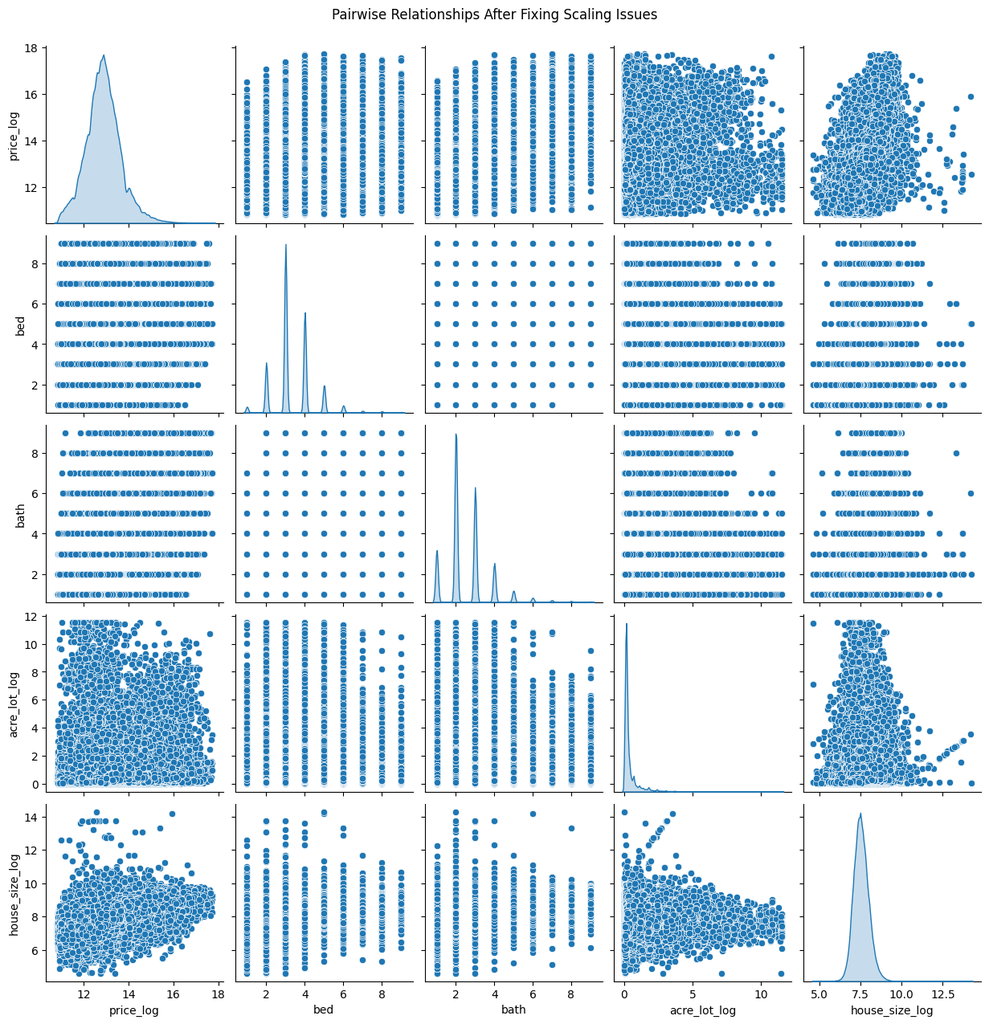

```python
# Apply Log to handle scaling issues
df_plot = df[:]
df_plot['price_log'] = np.log1p(df['price'])
df_plot['house_size_log'] = np.log1p(df['house_size'])
df_plot['acre_lot_log'] = np.log1p(df['acre_lot'])

sns.pairplot(
    df_plot,
    vars=['price_log', 'bed', 'bath', 'acre_lot_log', 'house_size_log'],
    diag_kind='kde'
)
plt.suptitle('Pairwise Relationships After Fixing Scaling Issues', y=1.02)
plt.show()
```

```python
# Save the cleaned dataset
df.to_csv('datasets/realtordataUS_cleaned.csv', index=False)
```

## Data Preproccessing

```python
df_cleaned = pd.read_csv('datasets/realtordataUS_cleaned.csv', encoding='UTF-8')
df_cleaned
```

|  | price | bed | bath | acre_lot | city | state | zip_code | house_size |
| --- | --- | --- | --- | --- | --- | --- | --- | --- |
| 0 | 105000.0 | 3.0 | 2.0 | 0.12 | Adjuntas | Puerto Rico | 601.0 | 920.0 |
| 1 | 80000.0 | 4.0 | 2.0 | 0.08 | Adjuntas | Puerto Rico | 601.0 | 1527.0 |
| 2 | 67000.0 | 2.0 | 1.0 | 0.15 | Juana Diaz | Puerto Rico | 795.0 | 748.0 |
| 3 | 145000.0 | 4.0 | 2.0 | 0.10 | Ponce | Puerto Rico | 731.0 | 1800.0 |
| 4 | 179000.0 | 4.0 | 3.0 | 0.46 | San Sebastian | Puerto Rico | 612.0 | 2520.0 |
| ... | ... | ... | ... | ... | ... | ... | ... | ... |
| 1239180 | 359900.0 | 4.0 | 2.0 | 0.33 | Richland | Washington | 99354.0 | 3600.0 |
| 1239181 | 350000.0 | 3.0 | 2.0 | 0.10 | Richland | Washington | 99354.0 | 1616.0 |
| 1239182 | 440000.0 | 6.0 | 3.0 | 0.50 | Richland | Washington | 99354.0 | 3200.0 |
| 1239183 | 179900.0 | 2.0 | 1.0 | 0.09 | Richland | Washington | 99354.0 | 933.0 |
| 1239184 | 580000.0 | 5.0 | 3.0 | 0.31 | Richland | Washington | 99354.0 | 3615.0 |

1239185 rows × 8 columns

Due to our computation limit, we will only use 43000 entries from state California

```python
df_california = df_cleaned[df_cleaned['state'] == 'California']
df_sample = df_california.sample(n=43000)
df_sample.to_csv('datasets/realtordataUS_cleaned_california_sample.csv', index=False)
df_remaining = df_california.drop(df_california.index)
df_remaining.to_csv('datasets/realtordataUS_cleaned_california_remaining.csv', index=False)
df_sample
```

|  | price | bed | bath | acre_lot | city | state | zip_code | house_size |
| --- | --- | --- | --- | --- | --- | --- | --- | --- |
| 679788 | 305000.0 | 3.0 | 2.0 | 0.35 | Pope Valley | California | 94567.0 | 1698.0 |
| 1202601 | 470740.0 | 3.0 | 2.0 | 0.31 | Plumas Lake | California | 95961.0 | 1818.0 |
| 1141229 | 581990.0 | 3.0 | 3.0 | 0.07 | Murrieta | California | 92563.0 | 1864.0 |
| 1190201 | 325000.0 | 3.0 | 2.0 | 0.37 | Pioneer | California | 95666.0 | 1724.0 |
| 1152366 | 190000.0 | 1.0 | 1.0 | 0.01 | Palm Springs | California | 92262.0 | 589.0 |
| ... | ... | ... | ... | ... | ... | ... | ... | ... |
| 1152496 | 369000.0 | 4.0 | 2.0 | 0.11 | La Quinta | California | 92253.0 | 1470.0 |
| 1171830 | 2400000.0 | 4.0 | 3.0 | 0.15 | Piedmont | California | 94610.0 | 3237.0 |
| 1181247 | 769950.0 | 4.0 | 3.0 | 0.12 | Tracy | California | 95377.0 | 2498.0 |
| 1165907 | 550000.0 | 4.0 | 3.0 | 0.32 | Bakersfield | California | 93312.0 | 2592.0 |
| 1120570 | 725000.0 | 3.0 | 2.0 | 0.23 | Los Angeles | California | 90006.0 | 1256.0 |

43000 rows × 8 columns

First, we convert the categorical location data (city, state, zip code) into numerical data. There is also an option to use Embedding layers, however that will limit our prediction inputs (since the categorical data of this dataset is not fixed)

```python
# Merge city, state, and zip_code into a location string for GeoPy API to convert to longitude and latitude coordinates
df_sample['zip_code'] = df_sample['zip_code'].astype(int)
df_sample['location'] = df_sample['city'] + ', ' + df_sample['state'] + ', ' + df_sample['zip_code'].astype(str)
df_sample
```

[output not shown]

43000 rows × 9 columns

Convert location string to longitude and latitude coordinates

```python
geolocator = Nominatim(user_agent='ontariotechu')

def get_long_lat_coordinates(location):
    try:
        loc = geolocator.geocode(location.split(',')[-1].strip()) # try with only the zip code
        if loc:
            return loc.latitude, loc.longitude
        else:
            loc = geolocator.geocode(location)
            if loc:
                return loc.latitude, loc.longitude
            else:
                return None, None
    except Exception as e:
        return None, None

df_sample_longlat = df_sample[:]
df_sample_longlat[['loc_lat', 'loc_long']] = df_sample_longlat.apply(lambda row: pd.Series(get_long_lat_coordinates(row['location'])), axis=1)
df_sample_longlat.to_csv('datasets/realtordataUS_cleaned_california_sample_longlat.csv', index=False)
```

```python
df_sample_longlat = pd.read_csv('datasets/realtordataUS_cleaned_california_sample_longlat.csv', encoding='UTF-8')
df_sample_longlat
```

|  | price | bed | bath | acre_lot | city | state | zip_code | house_size | location | loc_lat | loc_long |
| --- | --- | --- | --- | --- | --- | --- | --- | --- | --- | --- | --- |
| 0 | 305000 | 3 | 2 | 0.35 | Pope Valley | California | 94567 | 1698 | Pope Valley, California, 94567 | 38.615184 | -122.427757 |
| 1 | 470740 | 3 | 2 | 0.31 | Plumas Lake | California | 95961 | 1818 | Plumas Lake, California, 95961 | 39.020402 | -121.551226 |
| 2 | 581990 | 3 | 3 | 0.07 | Murrieta | California | 92563 | 1864 | Murrieta, California, 92563 | 33.560832 | -117.210656 |
| 3 | 325000 | 3 | 2 | 0.37 | Pioneer | California | 95666 | 1724 | Pioneer, California, 95666 | 38.431855 | -120.571872 |
| 4 | 190000 | 1 | 1 | 0.01 | Palm Springs | California | 92262 | 589 | Palm Springs, California, 92262 | 33.824627 | -116.540303 |
| ... | ... | ... | ... | ... | ... | ... | ... | ... | ... | ... | ... |
| 42995 | 369000 | 4 | 2 | 0.11 | La Quinta | California | 92253 | 1470 | La Quinta, California, 92253 | 33.677474 | -116.295879 |
| 42996 | 2400000 | 4 | 3 | 0.15 | Piedmont | California | 94610 | 3237 | Piedmont, California, 94610 | 37.824371 | -122.231635 |
| 42997 | 769950 | 4 | 3 | 0.12 | Tracy | California | 95377 | 2498 | Tracy, California, 95377 | 37.738551 | -121.420139 |
| 42998 | 550000 | 4 | 3 | 0.32 | Bakersfield | California | 93312 | 2592 | Bakersfield, California, 93312 | 35.373871 | -119.019463 |
| 42999 | 725000 | 3 | 2 | 0.23 | Los Angeles | California | 90006 | 1256 | Los Angeles, California, 90006 | 34.053691 | -118.242766 |

43000 rows × 11 columns

Then we have to convert longitude and latitude coordinates to the Earth's Cartesian coordinates, so that our model can do spatial calculation

```python
def get_cartesian_coordinates(df):
    df_cartesian = df[:]

    # Convert latitude and longitude to radians
    df_cartesian['loc_lat_rad'] = np.radians(df_cartesian['loc_lat'])
    df_cartesian['loc_long_rad'] = np.radians(df_cartesian['loc_long'])

    # Calculate Cartesian coordinates
    df_cartesian['loc_x'] = np.cos(df_cartesian['loc_lat_rad']) * np.cos(df_cartesian['loc_long_rad'])
    df_cartesian['loc_y'] = np.cos(df_cartesian['loc_lat_rad']) * np.sin(df_cartesian['loc_long_rad'])
    df_cartesian['loc_z'] = np.sin(df_cartesian['loc_lat_rad'])

    # Now we can remove all categorical columns and intermediate math columns
    df_out = df_cartesian.drop(columns=['city', 'state', 'zip_code', 'location', 'loc_lat', 'loc_long', 'loc_lat_rad', 'loc_long_rad'])
    return df_out # The Cartesian data is already normalized

df_sample_cartesian = get_cartesian_coordinates(df_sample_longlat)[:]
df_sample_cartesian
```

|  | price | bed | bath | acre_lot | house_size | loc_x | loc_y | loc_z |
| --- | --- | --- | --- | --- | --- | --- | --- | --- |
| 0 | 305000 | 3 | 2 | 0.35 | 1698 | -0.418991 | -0.659517 | 0.624087 |
| 1 | 470740 | 3 | 2 | 0.31 | 1818 | -0.406533 | -0.662072 | 0.629597 |
| 2 | 581990 | 3 | 3 | 0.07 | 1864 | -0.381037 | -0.741079 | 0.552822 |
| 3 | 325000 | 3 | 2 | 0.37 | 1724 | -0.398426 | -0.674456 | 0.621583 |
| 4 | 190000 | 1 | 1 | 0.01 | 589 | -0.371200 | -0.743202 | 0.556653 |
| ... | ... | ... | ... | ... | ... | ... | ... | ... |
| 42995 | 369000 | 4 | 2 | 0.11 | 1470 | -0.368658 | -0.746058 | 0.554517 |
| 42996 | 2400000 | 4 | 3 | 0.15 | 3237 | -0.421285 | -0.668171 | 0.613243 |
| 42997 | 769950 | 4 | 3 | 0.12 | 2498 | -0.412258 | -0.674853 | 0.612059 |
| 42998 | 550000 | 4 | 3 | 0.32 | 2592 | -0.395552 | -0.713023 | 0.578909 |
| 42999 | 725000 | 3 | 2 | 0.23 | 1256 | -0.392059 | -0.729879 | 0.559970 |

43000 rows × 8 columns

Finally, we should normalize our numeric features because the values range vastly across the dataset. This will ensure our data is on similar scales and this could improve our models performance down the line.

```python
# Initialize numerical scaler
numerical_features_to_scale = ['bed', 'bath', 'acre_lot', 'house_size']
scaler = StandardScaler()
scaler.fit(df_sample_cartesian[numerical_features_to_scale])
joblib.dump(scaler, "../app/feature_scaler.joblib")
price_scaler = StandardScaler()
price_scaler.fit(df_sample_cartesian[['price']])
joblib.dump(price_scaler, "../app/price_scaler.joblib")

# Transform sample data
df_inputs_norm = df_sample_cartesian[:]
df_inputs_norm[numerical_features_to_scale] = scaler.transform(df_inputs_norm[numerical_features_to_scale])
df_inputs_norm['price'] = price_scaler.transform(df_inputs_norm[['price']])
df_inputs_norm
```

|  | price | bed | bath | acre_lot | house_size | loc_x | loc_y | loc_z |
| --- | --- | --- | --- | --- | --- | --- | --- | --- |
| 0 | -0.493320 | -0.263561 | -0.478407 | -0.019058 | -0.180694 | -0.418991 | -0.659517 | 0.624087 |
| 1 | -0.384415 | -0.263561 | -0.478407 | -0.019089 | -0.083815 | -0.406533 | -0.662072 | 0.629597 |
| 2 | -0.311315 | -0.263561 | 0.436492 | -0.019278 | -0.046678 | -0.381037 | -0.741079 | 0.552822 |
| 3 | -0.480178 | -0.263561 | -0.478407 | -0.019042 | -0.159703 | -0.398426 | -0.674456 | 0.621583 |
| 4 | -0.568884 | -2.109199 | -1.393307 | -0.019325 | -1.076013 | -0.371200 | -0.743202 | 0.556653 |
| ... | ... | ... | ... | ... | ... | ... | ... | ... |
| 42995 | -0.451267 | 0.659258 | -0.478407 | -0.019247 | -0.364763 | -0.368658 | -0.746058 | 0.554517 |
| 42996 | 0.883267 | 0.659258 | 0.436492 | -0.019215 | 1.061774 | -0.421285 | -0.668171 | 0.613243 |
| 42997 | -0.187810 | 0.659258 | 0.436492 | -0.019239 | 0.465164 | -0.412258 | -0.674853 | 0.612059 |
| 42998 | -0.332335 | 0.659258 | 0.436492 | -0.019082 | 0.541052 | -0.395552 | -0.713023 | 0.578909 |
| 42999 | -0.217345 | -0.263561 | -0.478407 | -0.019152 | -0.537530 | -0.392059 | -0.729879 | 0.559970 |

43000 rows × 8 columns

Now we can start training our model

First, we initialize our models

```python
class LinearRegressionModel(nn.Module):
    def __init__(self, in_dims):
        super().__init__()
        self.nn = nn.Linear(in_dims, 1) # out dimension is 1, predicting the price

    def forward(self, x):
        return self.nn(x)
```

```python
class MLPRegressionModel(nn.Module):
    def __init__(self, in_dims):
        super().__init__()
        # Define the MLP architecture
        self.nn = nn.Sequential(
            nn.Linear(in_dims, 512),
            nn.ELU(), # Neurons with negative inputs won't become inactive
            nn.Dropout(0.15), # Add dropout with a 10% probability to reduce overfitting
            nn.Linear(512, 256),
            nn.ELU(),
            nn.Dropout(0.15),
            nn.Linear(256, 128),
            nn.ELU(),
            nn.Dropout(0.15),
            nn.Linear(128, 64),
            nn.ELU(),
            nn.Dropout(0.15),
            nn.Linear(64, 32),
            nn.ELU(),
            nn.Dropout(0.15),
            nn.Linear(32, 1)
        )

    def forward(self, x):
        return self.nn(x)
```

Next, we initialize training and testing DataLoader

```python
# Initialize training and testing DataLoader
X = df_inputs_norm.drop(columns=['price']).to_numpy()
y = df_inputs_norm['price'].to_numpy()

# Train-test split for model evaluation
X_train, X_test, y_train, y_test = train_test_split(X, y, train_size=0.8, shuffle=True)

# Convert to 2D PyTorch tensors
X_train = torch.tensor(X_train, dtype=torch.float32)
y_train = torch.tensor(y_train, dtype=torch.float32).reshape(-1, 1)
X_test = torch.tensor(X_test, dtype=torch.float32)
y_test = torch.tensor(y_test, dtype=torch.float32).reshape(-1, 1)
in_dims = X_train.shape[1]

# Create TensorDataset and DataLoader for batching
train_dataset = TensorDataset(X_train, y_train)
test_dataset = TensorDataset(X_test, y_test)

train_loader = DataLoader(train_dataset, batch_size=32, shuffle=True)
test_loader = DataLoader(test_dataset, batch_size=32, shuffle=False)
```

Train models and evaluate

```python
def train(model_class: nn.Module, n_epochs: int, weight_decay=0.0):
    model = model_class(in_dims)
    print(torchinfo.summary(model))

    # Loss function
    # loss_fn = nn.MSELoss() # Mean Squared Error
    loss_fn = nn.HuberLoss(delta=0.8) # less sensitive to outliers

    # Optimizer
    optimizer = torch.optim.Adam(model.parameters(), lr=0.001, weight_decay=weight_decay)

    # Learning rate scheduler: Reduce learning rate when validation loss plateaus
    scheduler = ReduceLROnPlateau(optimizer, mode='min', factor=0.2, patience=5, verbose=True)

    # Statistics
    best_train_mse = np.inf # Initialize to infinity
    best_mse = np.inf # Initialize to infinity
    best_weights = None
    history_mse = []
    history_r2 = []
    history_train_mse = []  # To store training MSE
    history_train_r2 = []  # To store training R2

    # Early stopping parameters
    patience = 20 # Number of epochs to wait for improvement
    epochs_without_improvement = 0 # Track epochs without improvement

    for epoch in range(n_epochs):
        model.train()

        # Variables to accumulate training loss and predictions
        total_train_loss = 0
        y_train_true_all = []
        y_train_pred_all = []

        with tqdm.tqdm(train_loader, unit="batch", mininterval=0, disable=True) as bar:
            bar.set_description(f"Epoch {epoch}")
            for X_batch, y_batch in bar:
                # Forward pass
                y_pred = model(X_batch)
                loss = loss_fn(y_pred, y_batch)
                # Backward pass
                optimizer.zero_grad()
                loss.backward()
                # Update weights
                optimizer.step()
                # Print progress
                bar.set_postfix(mse=float(loss))

                total_train_loss += loss.item()
                y_train_true_all.append(y_batch.cpu().numpy())
                y_train_pred_all.append(y_pred.cpu().detach().numpy())

        # Calculate training MSE
        train_mse = total_train_loss / len(train_loader)
        if train_mse < best_train_mse: best_train_mse = train_mse
        history_train_mse.append(train_mse)
        # Flatten training true and predicted values for R2 calculation
        y_train_true_all = np.concatenate(y_train_true_all, axis=0)
        y_train_pred_all = np.concatenate(y_train_pred_all, axis=0)
        # Calculate training R2
        train_r2 = r2_score(y_train_true_all, y_train_pred_all)
        history_train_r2.append(train_r2)

        # Evaluate accuracy at the end of each epoch
        model.eval()
        total_loss = 0
        y_true_all = []
        y_pred_all = []

        with torch.no_grad():
            for X_batch, y_batch in test_loader:
                y_pred = model(X_batch)
                loss = loss_fn(y_pred, y_batch)
                total_loss += loss.item()

                # Store true and predicted values for R2 calculation
                y_true_all.append(y_batch.cpu().numpy())
                y_pred_all.append(y_pred.cpu().numpy())

        mse = total_loss / len(test_loader)
        mse = float(mse)
        history_mse.append(mse)

        # Flatten true and predicted values for R2 calculation
        y_true_all = np.concatenate(y_true_all, axis=0)
        y_pred_all = np.concatenate(y_pred_all, axis=0)
        # Calculate R2
        r2 = r2_score(y_true_all, y_pred_all)
        history_r2.append(r2)

        if mse < best_mse:
            best_mse = mse
            best_weights = copy.deepcopy(model.state_dict())
            epochs_without_improvement = 0
        else:
            epochs_without_improvement += 1
            # If no improvement for 'patience' epochs, stop training
            if epochs_without_improvement >= patience:
                print(f"Early stopping at epoch {epoch+1}")
                break

        # Step the scheduler to adjust the learning rate based on validation loss
        scheduler.step(mse)

    # Restore model and return best accuracy
    model.load_state_dict(best_weights)
    print("Train MSE: %.2f" % best_train_mse)
    print("Train RMSE: %.2f" % np.sqrt(best_train_mse))
    print("Train R2: %.2f" % max(history_train_r2))
    print("MSE: %.2f" % best_mse)
    print("RMSE: %.2f" % np.sqrt(best_mse))
    print("R2: %.2f" % max(history_r2))

    # Plot MSE
    plt.subplot(1, 2, 1)
    plt.title('MSE Over Epochs')
    plt.plot(history_mse, label='Validation MSE')
    plt.plot(history_train_mse, label='Training MSE', linestyle='--')
    plt.xlabel('Epoch')
    plt.ylabel('MSE')
    plt.legend()

    # Plot R2
    plt.subplot(1, 2, 2)
    plt.title('R2 Over Epochs')
    plt.plot(history_r2, label='Validation R2', color='green')
    plt.plot(history_train_r2, label='Training R2', linestyle='--', color='red')
    plt.xlabel('Epoch')
    plt.ylabel('R2')
    plt.legend()
    plt.tight_layout()
    plt.show()

    return model
```

```
=================================================================
Layer (type:depth-idx)                   Param #
=================================================================
LinearRegressionModel                    --
├─Linear: 1-1                            8
=================================================================
Total params: 8
Trainable params: 8
Non-trainable params: 0
=================================================================
Epoch 00187: reducing learning rate of group 0 to 2.0000e-04.
Train MSE: 0.10
Train RMSE: 0.32
Train R2: 0.30
MSE: 0.10
RMSE: 0.31
R2: 0.36
```

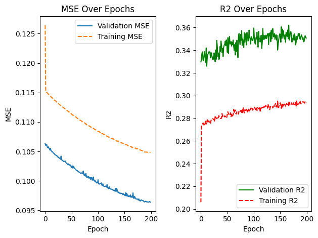

```python
lr_model = train(LinearRegressionModel, 200)
```

We can see that the simple linear regression model is too simple and underfitting for this dataset

However, using a MLP model with more layers will allow fine-tuning and improve performance

```
=================================================================
Layer (type:depth-idx)                   Param #
=================================================================
MLPRegressionModel                       --
├─Sequential: 1-1                        --
│    └─Linear: 2-1                       4,096
│    └─ELU: 2-2                          --
│    └─Dropout: 2-3                      --
│    └─Linear: 2-4                       131,328
│    └─ELU: 2-5                          --
│    └─Dropout: 2-6                      --
│    └─Linear: 2-7                       32,896
│    └─ELU: 2-8                          --
│    └─Dropout: 2-9                      --
│    └─Linear: 2-10                      8,256
│    └─ELU: 2-11                         --
│    └─Dropout: 2-12                     --
│    └─Linear: 2-13                      2,080
│    └─ELU: 2-14                         --
│    └─Dropout: 2-15                     --
│    └─Linear: 2-16                      33
=================================================================
Total params: 178,689
Trainable params: 178,689
Non-trainable params: 0
=================================================================
Epoch 00038: reducing learning rate of group 0 to 2.0000e-04.
Epoch 00063: reducing learning rate of group 0 to 4.0000e-05.
Epoch 00083: reducing learning rate of group 0 to 8.0000e-06.
Epoch 00089: reducing learning rate of group 0 to 1.6000e-06.
Epoch 00103: reducing learning rate of group 0 to 3.2000e-07.
Epoch 00109: reducing learning rate of group 0 to 6.4000e-08.
Epoch 00115: reducing learning rate of group 0 to 1.2800e-08.
Early stopping at epoch 117
Train MSE: 0.07
Train RMSE: 0.26
Train R2: 0.62
MSE: 0.07
RMSE: 0.26
R2: 0.62
```

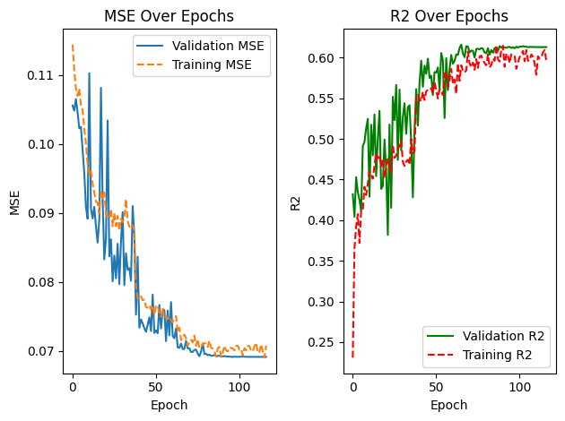

```python
mlp_model = train(MLPRegressionModel, 200)
```

We will use the MLP model for deployment

```
=================================================================
Layer (type:depth-idx)                   Param #
=================================================================
MLPRegressionModel                       --
├─Sequential: 1-1                        --
│    └─Linear: 2-1                       4,096
│    └─ELU: 2-2                          --
│    └─Dropout: 2-3                      --
│    └─Linear: 2-4                       131,328
│    └─ELU: 2-5                          --
│    └─Dropout: 2-6                      --
│    └─Linear: 2-7                       32,896
│    └─ELU: 2-8                          --
│    └─Dropout: 2-9                      --
│    └─Linear: 2-10                      8,256
│    └─ELU: 2-11                         --
│    └─Dropout: 2-12                     --
│    └─Linear: 2-13                      2,080
│    └─ELU: 2-14                         --
│    └─Dropout: 2-15                     --
│    └─Linear: 2-16                      33
=================================================================
Total params: 178,689
Trainable params: 178,689
Non-trainable params: 0
=================================================================
Epoch 00015: reducing learning rate of group 0 to 2.0000e-04.
Epoch 00048: reducing learning rate of group 0 to 4.0000e-05.
Epoch 00083: reducing learning rate of group 0 to 8.0000e-06.
Epoch 00094: reducing learning rate of group 0 to 1.6000e-06.
Epoch 00100: reducing learning rate of group 0 to 3.2000e-07.
Epoch 00106: reducing learning rate of group 0 to 6.4000e-08.
Early stopping at epoch 108
Train MSE: 0.07
Train RMSE: 0.27
Train R2: 0.61
MSE: 0.06
RMSE: 0.24
R2: 0.64
```

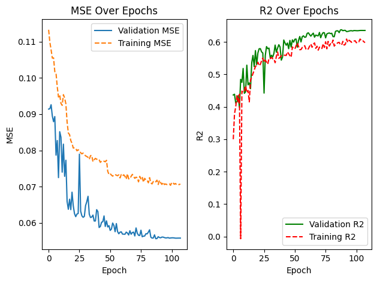

```python
X_train = torch.tensor(X, dtype=torch.float32)
y_train = torch.tensor(y, dtype=torch.float32).reshape(-1, 1)
in_dims = X_train.shape[1]

# Create TensorDataset and DataLoader for batching (using 100% data for training)
train_dataset = TensorDataset(X_train, y_train)
train_loader = DataLoader(train_dataset, batch_size=32, shuffle=True)

# Create and train model
mlp_model = train(MLPRegressionModel, 200)
```

```python
import onnx

mlp_model.eval()
torch.onnx.export(
    mlp_model,
    torch.randn(1, 7),
    "../app/my_model.onnx",
    export_params=True,
    opset_version=11,
    input_names=["input"],
    output_names=["output"],
    dynamic_axes={"input": {0: "batch_size"}, "output": {0: "batch_size"}}
)
```